© Guven

# Graph Neural Networks

## Introduction

In recent years, graph representation of data has become increasingly prevalent across various domains, from social networks to molecular biology. It is crucial to have a deep understanding of Graph Neural Networks (GNNs), which are designed specifically to handle graph-structured data.

One of the most striking examples is how a GNN model identified a new antibiotic. The model was trained on 2,500 molecules and was tested on a library of 6,000 compounds. It predicted that a molecule called halicin should be able to kill many antibiotic-resistant bacteria while having low toxicity to human cells.

GNNs are used for,

1. Node classification. Such as a task in a social network, using not only the original node features (such as name, age, and gender) but also information from edge features (such as the strength of relationships between nodes) and global features (such as network-wide statistics) to predict classes of nodes (e.g. leader vs follower).
2. Link prediction. Predicting missing links between pairs of nodes in a graph such as knowledge graph completion, where the goal is to complete a graph of entities and their relationships. It can also be used to predict the relationships between people based on their social network connections (friend recommendation).
3. Graph classification. A task that involves categorizing different graphs into predefined categories. Example in molecular biology, where molecular structures can be represented as graphs, and the goal is to predict their properties for drug design to categorize unseen graphs.
4. Graph generation. To generate new graphs based on a set of desired properties, such as a novel molecular structures for drug discovery. The generated structures can be evaluated for their potential as drug candidates and further studied.

## Graph Introduction

### Notations

- For a finite set $X$, $|X|$ denotes its size (cardinality, the number of its elements)
- Let $[1,n]=\{1,2,\dots,n\}$, and in general, $[i,n]=\{i,i+1,\dots,n\}$ for integers $i \le n$
- For a real number $x$, the floor and the ceiling of $x$ are the integers $\lfloor x \rfloor = \max \{ k \in \mathbb{Z} \mid k \le x \}$ and $\lceil x \rceil = \min \{k \in \mathbb{Z} \mid x \le k\}$
- A family $\{X_1,X_2,\dots,X_k\}$ of subsets $X_i \subseteq X$ of a set $X$ is a **partition** of $X$, if $X = \bigcup\limits_{i \in [1,k]} X_i$ and $X_i \cap X_j = \emptyset$ for all different $i$ and $j$
- For two sets $X$ and $Y$, $X \times Y = \{(x,y) \mid x \in X,y \in Y\}$ is their **Cartesian** product, and $X \Delta Y = (X \setminus Y) \cup (Y \setminus X)$ is their **symmetric** difference, where $X \setminus Y = \{x \mid x \in X, x \notin Y\}$
- Two integers $n,k \in \mathbb{N}$ (often $n=|X|$ and $k=|Y|$ for sets $X$ and $Y$) have the **same parity**, if both are even, or both are odd, if $n \equiv k$ (mod 2); otherwise, they have opposite parity

Most graph theory problems are NP-complete. A problem is in P if there is an efficient (polynomial) algorithm to find a solution. A problem is in NP, if it is first efficient to guess a solution, and then efficient to check that this solution is correct. It is conjectured (and not known) that P=NP. This is one of the millennium problems in modern mathematics and theoretical computer science. If the guessing in NP-problems can be replaced by an efficient systematic search for a solution, then P=NP. For anyone NP-complete problem, if it is in P, then necessarily P=NP.

Let $V$ be a finite set, and denote by $E(V)=\{\{u,v\} \mid u,v \in V, u \neq v\}$ the 2-sets (pairs) of $V$, i.e., subsets of two distinct elements.

A pair $G=(V,E)$ with $E \subseteq E(V)$ is called a graph (on $V$). The elements of $V$ are the vertices of $G$, and those of $E$ the edges of $G$. The vertex set of a graph $G$ is denoted by $V_G$ and its edge set by $E_G$. Therefore, $G=(V_G,E_G)$.

A pair $\{u,v\}$ is usually written simply as $uv$. Notice that then $uv = vu$. In order to simplify notations, we also write $v \in G$ and $e \in G$ instead of $v \in V_G$ and $e \in E_G$.

For a graph $G$, we denote $\nu_G = |V_G|$ and $\xi_G = |E_G|$

The number $\nu_G$ of the vertices is called the **order** of $G$, and $\xi_G$ is the **size** of $G$. For an edge $e=uv \in G$, the vertices $u$ and $v$ are its ends. Vertices $u$ and $v$ are adjacent or neighbors, if $uv \in G$. Two edges $e_1=uv$ and $e_2=uw$ having a common end, are adjacent with each other.

Graphs can be generalized by allowing loops $vv$ and parallel (or multiple) edges between vertices to obtain a **multigraph** $G=(V,E,y)$, where $E=\{e_1,e_2,\dots,e_m\}$ is a set (of symbols), and $y: E \to E(V) \cup \{vv \mid v \in V\}$ is a function that attaches an unordered pair of vertices to each $e \in E: \psi(e)=uv$.

Directed graphs or **digraphs** $D=(V,E)$, where the edges have a direction, or the edges are ordered: $E \subseteq V \times V$. In this case, $uv \neq vu$. A digraph can contain edges $uv$ and $vu$ of opposite directions. Graphs and digraphs can also be colored, labeled, and weighted.

A function $\alpha : V_G \to K$ is a vertex coloring of $G$ by a set $K$ of colors.

A function $\alpha : E_G \to K$ is an edge coloring of $G$. Usually, $K=[1,k]$ for some $k \ge 1$. If $K \subseteq \mathbb{R}$ (often $K \in \mathbb{N}$), then $\alpha$ is a weight function or a distance function.

## Example Graph Data

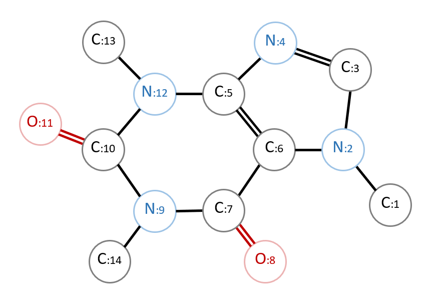

Molecules can be thought of as groups of atoms held together by chemical bonds. Among common elements are carbon (C), oxygen (O), nitrogen (N), and hydrogen (H). Some of the connections between atoms can be represented as single or double bonds. A molecule can be represented as an undirected graph with a node label matrix, where each row is a one-hot encoding of the node's atom type. The edge label matrix can have each row as a one-hot encoding of the associated edge's bond type. Consider the caffeine molecule example.

Adjacency $A=\begin{bmatrix} 0& 1& 0& \dots& 0 \\ 1& 0& 1& \dots& 0 \\ 0& 1& 0& \dots& 0 \\ \dots& \\ 0& 0& 0& \dots& 0 \end{bmatrix}$

Node labels, $V=\begin{bmatrix} 1& 0& 0\\ 0& 1& 0\\ 1& 0& 0\\ \dots\\ 1& 0& 0 \end{bmatrix}$, where columns are `C`, `N`, `O` in order.

Edge labels, $E=\begin{bmatrix} 1& 0\\ 1& 0\\ 1& 0\\ 0& 1\\ 1& 0\\ \dots\\ 1& 0 \end{bmatrix}$, where edges are `(1,2)`, `(2,3)`, etc., and first and seconds columns are single and double bonds, respectively.

## Example

The Cora dataset consists of 2708 scientific publications classified into one of seven classes. The citation network consists of 5429 links. Each publication in the dataset is described by a 0/1-valued word vector indicating the absence/presence of the corresponding word from the dictionary. The dictionary consists of 1433 unique words.

- `cora.cites` is the edge list file
  - 2708 nodes, 5429 edges
- `cora.content` is the node features file
  - M= 1433 binary features (words)
  - K= 7 classes

**Important** Note that the following GNN implementations create the NN layers in the constructor, thus `fit()` method does not behave like `scikit-learn` counterparts, i.e. the model is not reset.

Install PyTorch CUDA, igraph, and torch-geometric ([PyG](https://pytorch-geometric.readthedocs.io/en/latest/index.html)),

- `conda create -n gnn jupyter matplotlib pandas scikit-learn`↩
- `conda activate gnn`↩
- `conda install pytorch torchvision torchaudio pytorch-cuda=12.1 -c pytorch -c nvidia`↩
- `conda install -c conda-forge python-igraph cairocffi`↩
- `pip install torch-geometric`↩

```python
%matplotlib inline
import matplotlib.pyplot as plt
plt.rcParams["figure.dpi"] = 300
from IPython.display import display, Image
import numpy as np
import csv
import random
import sys

import torch
import torch.nn.functional as F

# Set the GPU to device 0
gpu = torch.device('cuda:0')

import igraph as ig
print(f'igraph version= {ig.__version__}')
print(f'torch version= {torch.__version__}')
print(f'CUDA available= {torch.cuda.is_available()}')
```

```
igraph version= 0.10.6
torch version= 2.0.1
CUDA available= True
```

```python
if torch.cuda.is_available():
    # CUDA Installation
    print('CUDA Version')
    !nvcc --version
    print()

    # CUDNN Installation
    print(f'CUDNN Version: {torch.backends.cudnn.version()}')
    print(f'Number of CUDA Devices: {torch.cuda.device_count()}')
    print(f'Active CUDA Device: {torch.cuda.current_device()}')
    print(f'Available devices: {torch.cuda.device_count()}, Name: {torch.cuda.get_device_name(0)}')
    print(f'Current CUDA device: {torch.cuda.current_device()}')
```

```
CUDA Version
nvcc: NVIDIA (R) Cuda compiler driver
Copyright (c) 2005-2023 NVIDIA Corporation
Built on Fri_Sep__8_19:56:38_Pacific_Daylight_Time_2023
Cuda compilation tools, release 12.3, V12.3.52
Build cuda_12.3.r12.3/compiler.33281558_0

CUDNN Version: 8500
Number of CUDA Devices: 1
Active CUDA Device: 0
Available devices: 1, Name: NVIDIA RTX 5000 Ada Generation
Current CUDA device: 0
```

```python
# visualizations
def gplot(_g, _ax, _layout, vertex_size=0.3, vertex_color='white', edge_width=0.7, gargs={}, title=None, targs={}):
    vnames = _g.vs['name'] if _g.is_named() else None
    ig.plot(_g, target=_ax, layout=_layout,
            vertex_size=vertex_size, vertex_label=vnames, vertex_color=vertex_color, edge_width=edge_width, **gargs)
    if title is not None:
        _ax.set_title(title, **targs)

def cplot(_g, _layout, vertex_size=5, vertex_color='white', edge_width=0.2, edge_color='dimgray',
          palette=None, bbox=(800,800)):
    fig_fn = '_cplot9.png'
    plot = ig.Plot(fig_fn, bbox=bbox, background='white')
    vs = { 'margin':10, 'layout':_layout, 'palette':palette,
           'vertex_size':vertex_size, 'vertex_color':vertex_color, 'vertex_label_size':3, 'edge_width':edge_width,
           'edge_color':edge_color, 'edge_arrow_size':0.03, 'edge_arrow_width':0.1, 'edge_curved':False}
    plot.add(_g, **vs)
    plot.save()
    display(Image(filename=fig_fn))
```

```python
# read Cora dataset
nodes, edges = set(), []
with open('../../../EP_datasets/graph/cora/cora.cites', 'r') as fin:
    csvreader = csv.reader(fin, delimiter='\t')
    for row in csvreader:
        v1, v2 = int(row[0]), int(row[1])
        edges += [(v1, v2)]
        nodes.update([v1,v2])
nodesIx = {v:i for i,v in enumerate(nodes)}
nodesIxRev = {i:v for v,i in nodesIx.items()}

N = max(nodesIx.values())+1
# update edges id
edges = [(nodesIx[v1],nodesIx[v2]) for v1, v2 in edges]

g_cora = ig.Graph(edges, directed=False)
ig.summary(g_cora)
```

```
IGRAPH U--- 2708 5429 --
```

```python
%%time
layout_fr = g_cora.layout_fruchterman_reingold(grid=False)
```

```
CPU times: total: 4.47 s
Wall time: 4.46 s
```

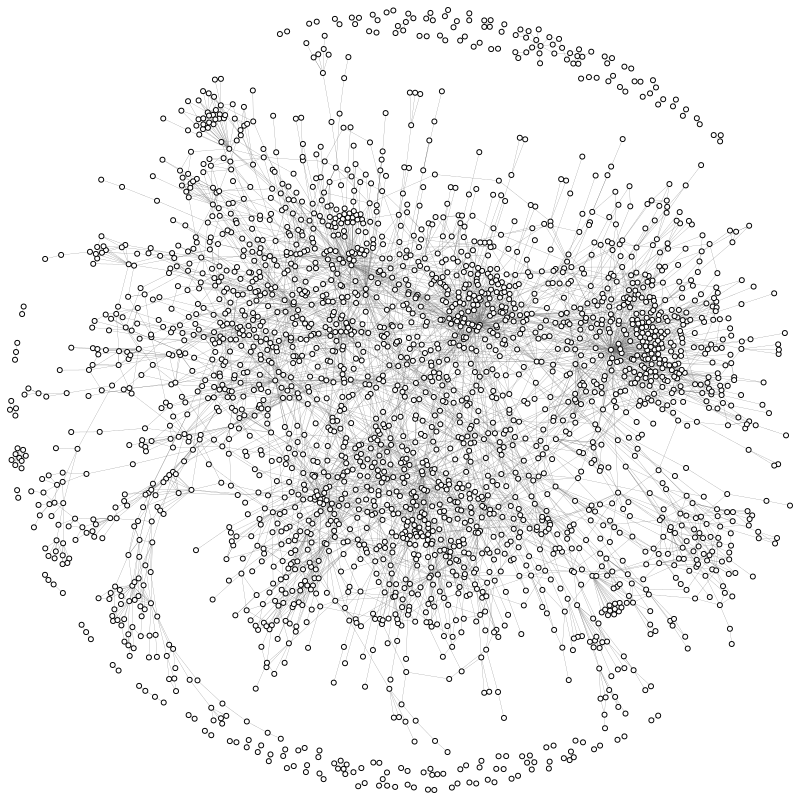

```python
cplot(g_cora, layout_fr)
```

```python
# read Cora node features
M = None
with open('../../../EP_datasets/graph/cora/cora.content', 'r') as fin:
    csvreader = csv.reader(fin, delimiter='\t')
    row = next(csvreader)
    M = len(row)-2  # excluding node id and class

X, y = np.zeros((N,M)), [None]*N
with open('../../../EP_datasets/graph/cora/cora.content', 'r') as fin:
    csvreader = csv.reader(fin, delimiter='\t')
    for row in csvreader:
        i = nodesIx[int(row[0])]
        X[i] = np.array(list(map(int, row[1:-1])))
        y[i] = row[-1]
```

```python
yIx = {c:i for i,c in enumerate(sorted(np.unique(y)))}
y = [yIx[_] for _ in y]

K = len(yIx)

# sanity
print(f'{M:d} features, {K:d} classes')
```

```
1433 features, 7 classes
```

```python
class Dataset:
    def __init__(self, _x, _y, _tram, _valm, _tesm, _edge_ix):
        self.x, self.y, self.train_mask, self.val_mask, self.test_mask = _x, _y, _tram, _valm, _tesm
        self.edge_index = _edge_ix

ix1 = random.sample(range(N), int(0.8*N))
ix2t = list(set(range(N))-set(ix1))
ix2 = random.sample(range(len(ix2t)), int(0.5*len(ix2t)))  # 0.1
ix2 = [ix2t[_] for _ in ix2]
ix3 = list(set(ix2t)-set(ix2))  # 0.1

# sanity
print(len(ix1), len(ix2), len(ix3), set(ix1)&set(ix2)&set(ix3)==set(), set(ix1)|set(ix2)|set(ix3)==set(range(N)))

tix1, tix2, tix3  = [False]*N, [False]*N, [False]*N
for _ in ix1:
    tix1[_] = True
for _ in ix2:
    tix2[_] = True
for _ in ix3:
    tix3[_] = True

cora = Dataset(torch.FloatTensor(X), torch.LongTensor(y), tix2, tix1, tix3,
               torch.LongTensor([[v1 for v1,v2 in g_cora.get_edgelist()]+[v2 for v1,v2 in g_cora.get_edgelist()],
                                 [v2 for v1,v2 in g_cora.get_edgelist()]+[v1 for v1,v2 in g_cora.get_edgelist()]]))

# edge list is symmetric for GCN
```

```
2166 271 271 True True
```

```python
# regular classifiers - caution: fit() will not reset

def accuracy(y_pred, y_true):
    return torch.sum(y_pred==y_true) / len(y_true)

class MLP(torch.nn.Module):
    def __init__(self, _dim_in, _dim_h, _dim_out):
        super().__init__()
        self.linear1 = torch.nn.Linear(_dim_in, _dim_h).to(gpu)
        self.linear2 = torch.nn.Linear(_dim_h, _dim_out).to(gpu)
    def forward(self, _X):
        _X = self.linear1(_X.to(gpu))
        _X = torch.relu(_X)
        _X = self.linear2(_X)
        return F.log_softmax(_X, dim=1).cpu()
    def fit(self, _dt, epochs=100, info=False):
        criterion = torch.nn.CrossEntropyLoss()
        optimizer = torch.optim.Adam(self.parameters(), lr=0.01, weight_decay=5e-4)
        self.train()
        for e in range(epochs+1):
            optimizer.zero_grad()
            out = self(_dt.x)
            loss = criterion(out[_dt.train_mask], _dt.y[_dt.train_mask])
            acc = accuracy(out[_dt.train_mask].argmax(dim=1), _dt.y[_dt.train_mask])
            loss.backward()
            optimizer.step()
            if e%20 == 0 and info:
                val_loss = criterion(out[_dt.val_mask],
                _dt.y[_dt.val_mask])
                val_acc = accuracy(out[_dt.val_mask].argmax(dim=1), _dt.y[_dt.val_mask])
                sys.stderr.write(f"\r{e:02d}/{epochs:02d} | Loss: {loss:<6.2f} | Tr Acc: {acc*100:3.2f}% | "
                                 f"Val Loss: {val_loss:<6.2f} | Val Acc: {val_acc*100:3.2f}%")
                sys.stderr.flush()
    @torch.no_grad()
    def test(self, _dt):
        self.eval()
        out = self(_dt.x)
        acc = accuracy(out.argmax(dim=1)[_dt.test_mask], _dt.y[_dt.test_mask])
        return acc
```

```python
# create the NN
mlp = MLP(M, 16, K).to(gpu)
print(mlp)
```

```
MLP(
  (linear1): Linear(in_features=1433, out_features=16, bias=True)
  (linear2): Linear(in_features=16, out_features=7, bias=True)
)
```

```python
mlp.fit(cora, info=True)
```

```
100/100 | Loss: 0.01   | Tr Acc: 100.00% | Val Loss: 1.17   | Val Acc: 62.19%
```

```python
Acc = mlp.test(cora)
print(f'MLP Acc: {Acc:.2f}')
```

```
MLP Acc: 0.61
```

## Graph Neural Networks

A linear layer can be modeled as $h_A = \sum\limits_{i \in \mathcal{N}_A} x_i W^\top$ where $\mathcal{N}_A$ is the neighborhood of node $A$. This corresponds $H=XW^\top$ in neural network layer computation where $X$ is the input matrix. If we use the graph adjacency matrix in place of $A$ then we convert the linear layer into a graph linear layer. Then, add **self loops** to the adjacency matrix by adding the identity matrix to $A$ which in effect adds the *attention* to the node itself. Thus, $\tilde{A} = A + \mathbf{I}$. The graph linear layer will become $H=\tilde{A}^\top X W^\top$.

As we continue the example, the performance will increase by adding the adjacency information to the GNN.

```python
class GNNLayer(torch.nn.Module):
    def __init__(self, _dim_in, _dim_out):
        super().__init__()
        self.linear = torch.nn.Linear(_dim_in, _dim_out, bias=False).to(gpu)
    def forward(self, _X, _adjacency):
        _X = self.linear(_X.to(gpu))
        _X = torch.sparse.mm(_adjacency.to(gpu), _X)
        return _X.cpu()
```

```python
# Graph Neural Network - caution: fit() will not reset

class GNN(torch.nn.Module):
    def __init__(self, _dim_in, _dim_h, _dim_out, _adjacency):
        super().__init__()
        self.gnn1 = GNNLayer(_dim_in, _dim_h)
        self.gnn2 = GNNLayer(_dim_h, _dim_out)
        self.adjacency = _adjacency
    def forward(self, _X):
        h = self.gnn1(_X, self.adjacency)
        h = torch.relu(h)
        h = self.gnn2(h, self.adjacency)
        return F.log_softmax(h, dim=1).cpu()
    def fit(self, _dt, epochs=100, info=False):
        criterion = torch.nn.CrossEntropyLoss()
        optimizer = torch.optim.Adam(self.parameters(), lr=0.01, weight_decay=5e-4)
        self.train()
        for e in range(epochs+1):
            optimizer.zero_grad()
            out = self(_dt.x)
            loss = criterion(out[_dt.train_mask], _dt.y[_dt.train_mask])
            acc = accuracy(out[_dt.train_mask].argmax(dim=1), _dt.y[_dt.train_mask])
            loss.backward()
            optimizer.step()
            if e%20 == 0 and info:
                val_loss = criterion(out[_dt.val_mask],
                _dt.y[_dt.val_mask])
                val_acc = accuracy(out[_dt.val_mask].argmax(dim=1), _dt.y[_dt.val_mask])
                sys.stderr.write(f"\r{e:02d}/{epochs:02d} | Loss: {loss:<6.2f} | Tr Acc: {acc*100:3.2f}% | "
                                 f"Val Loss: {val_loss:<6.2f} | Val Acc: {val_acc*100:3.2f}%")
                sys.stderr.flush()
    @torch.no_grad()
    def test(self, _dt):
        self.eval()
        out = self(_dt.x)
        acc = accuracy(out.argmax(dim=1)[_dt.test_mask], _dt.y[_dt.test_mask])
        return acc
```

```python
# adjacency matrix
cora_adj = torch.FloatTensor(g_cora.get_adjacency().data) + torch.eye(N)
```

```python
gnn = GNN(M, 16, K, cora_adj).to(gpu)
print(gnn)
```

```
GNN(
  (gnn1): GNNLayer(
    (linear): Linear(in_features=1433, out_features=16, bias=False)
  )
  (gnn2): GNNLayer(
    (linear): Linear(in_features=16, out_features=7, bias=False)
  )
)
```

```python
gnn.fit(cora, info=True)
```

```
100/100 | Loss: 0.01   | Tr Acc: 100.00% | Val Loss: 1.44   | Val Acc: 78.58%
```

```python
Acc = gnn.test(cora)
print(f'GNN Acc: {Acc:.2f}')
```

```
GNN Acc: 0.78
```

## Graph Convolutional Networks

The Graph Convolutional Network (GCN) architecture is an approximation of a graph convolution operation in graph signal processing. Unlike tabular or image data, nodes do not always have the same number of neighbors. Given the embedding of a node $h_i = \sum\limits_{j \in \mathcal{N}_i} x_j W^\top$ the GNN layer has the normalization factor of the number of degrees of the node. Specifically, $h_i =\frac{1}{\deg(i)}\sum\limits_{j \in \mathcal{N}_i} x_j W^\top$ is the updated GNN layer. Next, we use the degree matrix $D=\begin{bmatrix} \deg(0)& 0& \dots& 0 \\ 0& \deg(1)& \dots& 0 \\ \vdots& \vdots& \ddots& \vdots \\ 0& 0& \dots& \deg(m) \end{bmatrix}$.

Then add the identity matrix and take the inverse of $D$ to normalize, and then the GNN layer becomes,

- $\tilde{D}^{-1} \tilde{A} X W^\top$ to normalize row features
- $\tilde{A} \tilde{D}^{-1} X W^\top$ to normalize column features

The GCN layer becomes $H=\tilde{D}^{-\frac{1}{2}} \tilde{A}^\top \tilde{D}^{-\frac{1}{2}} X W^\top$.

```python
from torch_geometric.nn import GCNConv

class GCN(torch.nn.Module):
    def __init__(self, _dim_in, _dim_h, _dim_out):
        super().__init__()
        self.gcn1 = GCNConv(_dim_in, _dim_h, bias=False).to(gpu)
        self.gcn2 = GCNConv(_dim_h, _dim_out, bias=False).to(gpu)
    def forward(self, _X, _edge_ix):
        h = self.gcn1(_X.to(gpu), _edge_ix.to(gpu))
        h = torch.relu(h)
        h = self.gcn2(h, _edge_ix.to(gpu))
        return F.log_softmax(h, dim=1).cpu()
    def fit(self, _dt, epochs=100, info=False):
        criterion = torch.nn.CrossEntropyLoss()
        optimizer = torch.optim.Adam(self.parameters(), lr=0.01, weight_decay=5e-4)
        self.train()
        for e in range(epochs+1):
            optimizer.zero_grad()
            out = self(_dt.x, _dt.edge_index)
            loss = criterion(out[_dt.train_mask], _dt.y[_dt.train_mask])
            acc = accuracy(out[_dt.train_mask].argmax(dim=1), _dt.y[_dt.train_mask])
            loss.backward()
            optimizer.step()
            if e%20 == 0 and info:
                val_loss = criterion(out[_dt.val_mask], _dt.y[_dt.val_mask])
                val_acc = accuracy(out[_dt.val_mask].argmax(dim=1), _dt.y[_dt.val_mask])
                sys.stderr.write(f"\r{e:02d}/{epochs:02d} | Loss: {loss:<6.2f} | Tr Acc: {acc*100:3.2f}% | "
                                 f"Val Loss: {val_loss:<6.2f} | Val Acc: {val_acc*100:3.2f}%")
                sys.stderr.flush()
    @torch.no_grad()
    def test(self, _dt):
        self.eval()
        out = self(_dt.x, _dt.edge_index)
        acc = accuracy(out.argmax(dim=1)[_dt.test_mask], _dt.y[_dt.test_mask])
        return acc
```

```python
gcn = GCN(M, 16, K).to(gpu)
print(gcn)
```

```
GCN(
  (gcn1): GCNConv(1433, 16)
  (gcn2): GCNConv(16, 7)
)
```

```python
gcn.fit(cora, info=True)
```

```
100/100 | Loss: 0.03   | Tr Acc: 100.00% | Val Loss: 0.56   | Val Acc: 82.36%
```

```python
Acc = gcn.test(cora)
print(f'GCN Acc: {Acc:.2f}')
```

```
GCN Acc: 0.81
```

## Graph Attention Networks

Graph Attention Networks (GATs) are a theoretical improvement over GCNs. Instead of static normalization coefficients, they propose weighting factors calculated by a process called self-attention. The same process is at the core of the transformer, popularized by BERT, GPT-x, etc.

The main idea behind GATs is that some nodes are more important than others. In fact, this was already the case with the graph convolutional layer: nodes with few neighbors were more important than others, thanks to the normalization coefficient $\frac{1}{\sqrt{\deg(i)} \sqrt{\deg(j)}}$. However, this approach is limiting because it only takes node degrees into account. On the other hand, the goal of the graph attention layer is to produce weighting factors that also consider the importance of node features. Denote weighting factors attention scores, the attention score between node $i$ and $j$ as $\alpha_{ij}$. Then the GAT layer becomes $h_i = \sum\limits_{j \in \mathcal{N}_i} \alpha_{ij} x_j \mathbf{W} x_j$.

```python
from torch_geometric.nn import GATv2Conv

class GAT(torch.nn.Module):
    def __init__(self, _dim_in, _dim_h, _dim_out, heads=8):
        super().__init__()
        self.gat1 = GATv2Conv(_dim_in, _dim_h, heads=heads, bias=False)
        self.gat2 = GATv2Conv(_dim_h*heads, _dim_out, heads=1, bias=False)
    def forward(self, _X, _edge_ix):
        h = F.dropout(_X.to(gpu), p=0.6, training=self.training)
        h = self.gat1(h, _edge_ix.to(gpu))
        h = F.elu(h)
        h = F.dropout(h, p=0.6, training=self.training)
        h = self.gat2(h, _edge_ix.to(gpu))
        return F.log_softmax(h, dim=1).cpu()
    def fit(self, _dt, epochs=100, info=False):
        criterion = torch.nn.CrossEntropyLoss()
        optimizer = torch.optim.Adam(self.parameters(), lr=0.01, weight_decay=5e-4)
        self.train()
        for e in range(epochs+1):
            optimizer.zero_grad()
            out = self(_dt.x, _dt.edge_index)
            loss = criterion(out[_dt.train_mask], _dt.y[_dt.train_mask])
            acc = accuracy(out[_dt.train_mask].argmax(dim=1), _dt.y[_dt.train_mask])
            loss.backward()
            optimizer.step()
            if e%20 == 0 and info:
                val_loss = criterion(out[_dt.val_mask], _dt.y[_dt.val_mask])
                val_acc = accuracy(out[_dt.val_mask].argmax(dim=1), _dt.y[_dt.val_mask])
                sys.stderr.write(f"\r{e:02d}/{epochs:02d} | Loss: {loss:<6.2f} | Tr Acc: {acc*100:3.2f}% | "
                                 f"Val Loss: {val_loss:<6.2f} | Val Acc: {val_acc*100:3.2f}%")
                sys.stderr.flush()
    @torch.no_grad()
    def test(self, _dt):
        self.eval()
        out = self(_dt.x, _dt.edge_index)
        acc = accuracy(out.argmax(dim=1)[_dt.test_mask], _dt.y[_dt.test_mask])
        return acc
```

```python
gat = GAT(M, 16, K).to(gpu)
print(gat)
```

```
GAT(
  (gat1): GATv2Conv(1433, 16, heads=8)
  (gat2): GATv2Conv(128, 7, heads=1)
)
```

```python
gat.fit(cora, info=True)
```

```
100/100 | Loss: 0.03   | Tr Acc: 99.26% | Val Loss: 0.94   | Val Acc: 76.41%
```

```python
Acc = gat.test(cora)
print(f'GAT Acc: {Acc:.2f}')
```

```
GAT Acc: 0.82
```

## Example Facebook Page-Page Dataset

The dataset has 22470 nodes which represent official Facebook pages. Pages are connected when there are mutual likes between them. Node features are 128-dimensional vectors created from textual descriptions written by the owners of these pages. Dataset has four categories: politicians, companies, television shows, and governmental organizations.

```python
from torch_geometric.datasets import FacebookPagePage
from torch_geometric.utils import to_dense_adj

# prep the data and validation, etc.
ds = FacebookPagePage(root='../../../EP_datasets/graph/fbdata')
fb = ds[0]
fb.train_mask = range(18000)
fb.val_mask = range(18001, 20000)
fb.test_mask = range(20001, 22470)

# metadata
M = fb.x.shape[1]
K = len(np.unique(fb.y))

# adjacency matrix tilde_A
fb_adjacency = to_dense_adj(fb.edge_index)[0]
fb_adjacency += torch.eye(len(fb_adjacency))
```

```python
mlp = MLP(M, 16, K).to(gpu)
mlp.fit(fb)
print(f'MLP Acc: {mlp.test(fb):.2f}')
```

```
MLP Acc: 0.75
```

```python
gnn = GNN(M, 16, K, fb_adjacency).to(gpu)
gnn.fit(fb)
print(f'GNN Acc: {gnn.test(fb):.2f}')
```

```
GNN Acc: 0.81
```

```python
gcn = GCN(M, 16, K).to(gpu)
gcn.fit(fb)
print(f'GCN Acc: {gcn.test(fb):.2f}')
```

```
GCN Acc: 0.91
```

```python
gat = GAT(M, 16, K).to(gpu)
gat.fit(fb)
print(f'GAT Acc: {gat.test(fb):.2f}')
```

```
GAT Acc: 0.92
```

## References

1. Artificial intelligence yields new antibiotic. https://news.mit.edu/2020/artificial-intelligence-identifies-new-antibiotic-0220. Accessed June 2023.
2. Labonne, Maxim. Hands-On Graph Neural Networks Using Python. Packt, 2023.
3. Berg, Rianne van den, Thomas N. Kipf, and Max Welling. "Graph convolutional matrix completion." arXiv preprint arXiv:1706.02263 (2017).
4. Veličković, Petar, et al. "Graph attention networks." arXiv preprint arXiv:1710.10903 (2017).
5. Rozemberczki, Benedek, Oliver Kiss, and Rik Sarkar. "Karate Club: an API oriented open-source python framework for unsupervised learning on graphs." Proceedings of the 29th ACM international conference on information & knowledge management. 2020.
6. PyG Documentation. https://pytorch-geometric.readthedocs.io/en/latest/index.html. Accessed July 2023.
7. Raschka, Sebastian, et al. Machine Learning with PyTorch and Scikit-Learn: Develop machine learning and deep learning models with Python. Packt Publishing Ltd, 2022.

## Exercises

**Exercise 1.** Examine the layer creation in all four NN architectures MLP, GNN, GCN, and GAT. Check out the layers from PyG website.

**Exercise 2.** Update the `GCN` to switch to `ChebConv` layers and attempt to improve the performance on Cora dataset. Use PyG website for reference.

```python
%%html
<style>
    table {margin-left: 0 !important;}
</style>
<!-- Display markdown tables left oriented in this notebook. -->
```